# Tp53 SNV hotspots

K S Gaonkar (D3B)

In this notebook we will add TP53 alteration status as discussed in [#837](https://github.com/AlexsLemonade/OpenPBTA-analysis/issues/837):

**TP53 altered - loss**, if :

- A sample contains a TP53 hotspot SNV mutation. (Cancer hotspot database and downloadable file available). Please also crosscheck that all mutations from this table are included.
- A sample contains two TP53 alterations, suggesting (but not confirming) that both alleles are affected (SNV+SNV, (CNV or SV) + SNV).
- A sample contains one alteration (SNV or (CNV or SV)) + has cancer_predispositions == “Li-Fraumeni syndrome”, suggesting there is a germline variant in addition to the somatic variant we observe.
- A sample does not have a TP53 alterations, but has cancer_predispositions == “Li-Fraumeni syndrome” and TP53 classifier score for matched RNA-Seq > 0.5 (or higher cutoff we decide upon later).

Note: CNV and SV will be considered as the same event, but we will be adding SV_counts and SV.type to the altered status output file

**TP53 altered - activated**, if:

- A sample contains one of the two TP53 activating mutations R273C and R248W. Reference and reference.

## Setup

```r
suppressPackageStartupMessages({
  library(plyr)
  library(ggpubr)
  library(ggthemes)
  library(tidyverse)
  library(ggfortify)
  library(broom)
})

# rootdir
root_dir <- rprojroot::find_root(rprojroot::has_dir(".git"))
data_dir <- file.path(root_dir, "data")
source(file.path('util', 'plot_by_cancer_predisposition.R'))

input_dir <- file.path(root_dir,
                       "analyses",
                       "tp53_nf1_score",
                       "input")

plot_dir <- file.path(root_dir,
                      "analyses",
                      "tp53_nf1_score",
                      "plots")

if (!dir.exists(plot_dir)) {
  dir.create(plot_dir)
}

# results directory
results_dir <- file.path(root_dir,
                         "analyses",
                         "tp53_nf1_score",
                         "results")

if (!dir.exists(results_dir)) {
  dir.create(results_dir)
}
# Save also as `polya_results_dir` to always read in polyA results properly
polya_results_dir <- results_dir


# cell composition
cell_line_composition <- read_tsv(file.path("..",
                                            "molecular-subtyping-HGG",
                                            "input",
                                            "cell-line-composition.tsv"),
                                  col_types =
                                    readr::cols( aliquot_id  = readr::col_character()))

# histology
if ( params$base_run ==0 ){
  clinical<-read.delim(file.path(data_dir,"pbta-histologies.tsv"), stringsAsFactors = FALSE)
} else{
  clinical<-read.delim(file.path(data_dir,"pbta-histologies-base.tsv"), stringsAsFactors = FALSE)
}

histology <- clinical %>%
  dplyr::select("Kids_First_Biospecimen_ID",
                "sample_id",
                "cancer_predispositions",
                "sample_type",
                "experimental_strategy",
                "composition") %>%
  # merge cell line composition
  left_join(cell_line_composition)


# Define a filename "suffix" that indicates tumor purity thresholded vs. regular files
# specifically relevant for **stranded** data
# We'll also want to update the output directory name for results
if (params$tumor_purity_threshold == 1) {
  tumor_purity_suffix <- "_tumor-purity-threshold"

  # Update results_dir name
  results_dir <- file.path(results_dir, "tumor-purity-threshold")
  if (!dir.exists(results_dir)) {
    dir.create(results_dir)
  }

} else {
  tumor_purity_suffix <- ""
}


# Cancer database
hotspot_database_2017_tp53_snv <- readxl::read_xls(file.path(input_dir,"hotspots_v2.xls"),sheet = 1) %>%
  filter(Hugo_Symbol == "TP53")
hotspot_database_2017_tp53_indel <- readxl::read_xls(file.path(input_dir,"hotspots_v2.xls"),sheet = 2) %>%
  filter(Hugo_Symbol == "TP53")

# p53, p63 and p73 functional sites
functional_sites_tp53 <- read_tsv(file.path(input_dir,"hotspot_Chen_2006.tsv"))


# classifier scores
classifier_score_stranded <- read_tsv(
  file.path(
    results_dir,
    glue::glue("pbta-gene-expression-rsem-fpkm-collapsed.stranded_classifier_scores{tumor_purity_suffix}.tsv")
  )) %>%
  dplyr::select(sample_id,tp53_score)

classifier_score_polya <-read_tsv(
  file.path(
    polya_results_dir,
    "pbta-gene-expression-rsem-fpkm-collapsed.polya_classifier_scores.tsv")) %>%
  dplyr::select(sample_id,tp53_score)

classifier_score <- rbind(classifier_score_polya,classifier_score_stranded) %>%
  dplyr::rename(Kids_First_Biospecimen_ID_RNA=sample_id) %>%
  left_join(histology ,by=c("Kids_First_Biospecimen_ID_RNA"="Kids_First_Biospecimen_ID"))

# Copy number per sample
# overlapping functional domain
cnv_domain_overlap <- read_tsv(
  file.path(
    results_dir,
    glue::glue("loss_overlap_domains_tp53{tumor_purity_suffix}.tsv")))

# Structural variant overlapping
# or within gene locus of TP53
sv_overlap <- read_tsv(
  file.path(
    results_dir,
    glue::glue("sv_overlap_tp53{tumor_purity_suffix}.tsv")))

# Structural variant as a fusion in exon1/intron1
fusion_overlap <- read_tsv(
  file.path(
    results_dir,
    glue::glue("fusion_bk_tp53_loss{tumor_purity_suffix}.tsv")))
```

### Check if all function sites are in hotspots

All functional sites are just 1 base so checking in `hotspot_database_2017_snv`

```r
functional_sites_tp53 %>%
  filter(!gsub("[A-Z|a-z]","",p53) %in% hotspot_database_2017_tp53_snv$Amino_Acid_Position )
```

| p53 | p63 | p73 |
| --- | --- | --- |
| A276 | A307 | A296 |
| R283 | K314 | K303 |

2 functional sites are missing in hotspots database.

## SNV for TP53

- We will use the `pbta-snv-consensus-mutation.maf.tsv.gz` from `snv-callers` module which gathers calls that are present in all 3 callers (strelka2,mutect2 and lancet)
- In addition, we will also use `pbta-snv-scavenged-hotspots.maf.tsv.gz` from `hotspot-detection` module to gather calls that overlap MSKCC hotspots found in any caller (except if only vardict calls the site as variant, we remove these calls since we have a lot of calls unique to vardict which we consider as false positive as discussed [here](https://github.com/AlexsLemonade/OpenPBTA-analysis/tree/master/analyses/snv-callers#snv-caller-comparison-analysis))
- We will also removing `Silent` or `Intron` classified variants to capture only putative damaging mutations

```r
tp53_consensus_maf <- data.table::fread(
  file.path(root_dir, "data" , "pbta-snv-consensus-mutation.maf.tsv.gz"),
  select = c("Chromosome",
             "Start_Position",
             "End_Position",
             "Strand",
             "Variant_Classification",
             "Tumor_Sample_Barcode",
             "Hugo_Symbol",
             "HGVSp_Short"),
  data.table = FALSE) %>%
  filter(Hugo_Symbol == "TP53")
tp53_hotspot_maf <- data.table::fread(
  file.path(root_dir, "analyses" , "hotspots-detection" , "results" , "pbta-snv-scavenged-hotspots.maf.tsv.gz"),
  select = c("Chromosome",
             "Start_Position",
             "End_Position",
             "Strand",
             "Variant_Classification",
             "Tumor_Sample_Barcode",
             "Hugo_Symbol",
             "HGVSp_Short"),
  data.table = FALSE) %>%
  filter(Hugo_Symbol == "TP53") %>%
  dplyr::select(colnames(tp53_consensus_maf))


tp53_consensus_hotspot_maf <- tp53_consensus_maf %>%
  bind_rows(tp53_hotspot_maf) %>%
  filter(!(Variant_Classification %in% c("Silent", "Intron",
                                         # remove other non-amino acid SNVs
                                         "3'Flank" ,"5'Flank",
                                         "3'UTR", "5'UTR"  ))) %>%
  unique()
```

### Gather annotation for SNV

hotspots : overlaps AA position which are statistically significant SNV/Indels activating : overlaps AA position which are found to act as gain-of-function according to literature

```r
tp53_consensus_hotspot_maf  <- tp53_consensus_hotspot_maf  %>%
  mutate(
    hotspot = case_when(
      # strip REF and Variant AA to get Amino_Acid_Position in consensus maf
      (gsub("[A-Z|a-z]|[.]","",HGVSp_Short) %in%
         # if overlaps the hotspot Amino_Acid_Position
         hotspot_database_2017_tp53_snv$Amino_Acid_Position)  ~ 1,
      TRUE ~ 0),
    activating = case_when(
      # strip REF and Variant AA to get Amino_Acid_Position in consensus maf
      (gsub("[A-Z|a-z]|[.]","",HGVSp_Short) %in%
         # if overlaps the activating  Amino_Acid_Position
         c("273","248"))  ~ 1,
      TRUE ~ 0
    )
  )
```

## Gather SNV,CNV, classifier and cancer_predisposition values

We will gather values per sample_id since DNA and RNA samples can be only matched by `sample_id`

```r
tp53_alterations <- histology %>%
  filter(experimental_strategy != "RNA-Seq") %>%
  # merge cell line composition
  left_join(cell_line_composition) %>%
  # filter for Tumors
  filter(sample_type=="Tumor") %>%
  # join consensus calls overlapping hotspots
  left_join(tp53_consensus_hotspot_maf ,
            by=c("Kids_First_Biospecimen_ID"="Tumor_Sample_Barcode")) %>%
  # join filtered cnv losses
  left_join(cnv_domain_overlap,by=c("Kids_First_Biospecimen_ID"="biospecimen_id",
                                    "sample_id")) %>%
  # join SV
  left_join(sv_overlap,by=c("Kids_First_Biospecimen_ID"="Kids.First.Biospecimen.ID.Tumor",
                            "sample_id")) %>%
  dplyr::rename(Kids_First_Biospecimen_ID_DNA = Kids_First_Biospecimen_ID) %>%
  # join fusion
  left_join(fusion_overlap,by="sample_id")

tp53_alterations_score <- tp53_alterations %>%
  # add classifier score
  full_join(classifier_score,by=c("sample_id",
                                  "cell_line_composition",
                                  "cancer_predispositions",
                                  "sample_type",
                                  "Kids_First_Participant_ID")) %>%
  # select useful columns
  dplyr::select(sample_id,Kids_First_Biospecimen_ID_RNA,Kids_First_Biospecimen_ID_DNA,
                tp53_score,cancer_predispositions,HGVSp_Short,copy_number,SV.type,FusionName,hotspot,activating) %>%
  arrange(sample_id) %>%
  unique() %>%
  replace_na(list(hotspot = 0, activating = 0))

tp53_alterations_score
```

|  | sample_id | Kids_First_Biospecimen_ID_RNA | Kids_First_Biospecimen_ID_DNA | tp53_score | cancer_predispositions | HGVSp_Short | copy_number | SV.type | FusionName | hotspot | activating |
| --- | --- | --- | --- | --- | --- | --- | --- | --- | --- | --- | --- |
| 1 | 7316-10 | BS_GDHH6T5A | BS_1RFBH1SP | 0.234013268 | NF-1 | NA | NA | NA | NA | 0 | 0 |
| 2 | 7316-100 | BS_BHR08WGW | BS_SFZ3A07S | 0.408437231 | None documented | NA | NA | NA | NA | 0 | 0 |
| 3 | 7316-101 | BS_QV51J756 | BS_4RS1SC48 | 0.610204679 | None documented | NA | NA | NA | NA | 0 | 0 |
| 4 | 7316-1038 | BS_VPBMDMQX | NA | 0.779885950 | None documented | NA | NA | NA | NA | 0 | 0 |
| 5 | 7316-104 | BS_Y08D5P8N | BS_MRX1SPFB | 0.251792802 | None documented | NA | NA | NA | NA | 0 | 0 |
| 6 | 7316-1052 | BS_TGS109T3 | NA | 0.851979088 | None documented | NA | NA | NA | NA | 0 | 0 |
| 7 | 7316-1055 | BS_H1ZS5FMZ | NA | 0.903653521 | None documented | NA | NA | NA | NA | 0 | 0 |
| 8 | 7316-1057 | BS_58YXHGAJ | NA | 0.575641146 | None documented | NA | NA | NA | NA | 0 | 0 |
| 9 | 7316-1059 | BS_C41DJZ1F | NA | 0.442783151 | NF-1 | NA | NA | NA | NA | 0 | 0 |
| 10 | 7316-1060 | BS_Z8F3GM85 | NA | 0.845250771 | None documented | NA | NA | NA | NA | 0 | 0 |

[output cut: 1155 more lines]

Convert the above to wide format

```r
tp53_alterations_score_wide <- tp53_alterations_score %>%
  # group
  group_by(sample_id,
           Kids_First_Biospecimen_ID_DNA,
           Kids_First_Biospecimen_ID_RNA,
           cancer_predispositions,
           tp53_score) %>%
  #
  # sample_id as rows add SNV counts,CNV loss counts
  # and hotspot/activating mutation annotation
  summarise(
    # summarize length of SNV and CNV alterations
    SNV_indel_counts= length(unique(HGVSp_Short[!is.na(HGVSp_Short)])),
    CNV_loss_counts = length(unique(copy_number[!is.na(copy_number)])),
    SV_counts = length(unique(SV.type[!is.na(SV.type)])),
    Fusion_counts = length(unique(FusionName[!is.na(FusionName)])),
    HGVSp_Short = toString(unique(HGVSp_Short)),
    CNV_loss_evidence = toString(unique(copy_number)),
    SV_type = toString(unique(SV.type)),
    Fusion_evidence = toString(unique(FusionName)),
    # summarize unique hotspot values per sample_id
    hotspot = max(unique(hotspot[!is.na(hotspot) ])),
    activating = max(unique(activating[!is.na(activating)])))

tp53_alterations_score_wide
```

| sample_id | Kids_First_Biospecimen_ID_DNA | Kids_First_Biospecimen_ID_RNA | cancer_predispositions | tp53_score | SNV_indel_counts | CNV_loss_counts | SV_counts | Fusion_counts | HGVSp_Short | CNV_loss_evidence | SV_type | Fusion_evidence | hotspot | activating |
| --- | --- | --- | --- | --- | --- | --- | --- | --- | --- | --- | --- | --- | --- | --- |
| 7316-10 | BS_1RFBH1SP | BS_GDHH6T5A | NF-1 | 0.234013268 | 0 | 0 | 0 | 0 | NA | NA | NA | NA | 0 | 0 |
| 7316-100 | BS_SFZ3A07S | BS_BHR08WGW | None documented | 0.408437231 | 0 | 0 | 0 | 0 | NA | NA | NA | NA | 0 | 0 |
| 7316-101 | BS_4RS1SC48 | BS_QV51J756 | None documented | 0.610204679 | 0 | 0 | 0 | 0 | NA | NA | NA | NA | 0 | 0 |
| 7316-1038 | NA | BS_VPBMDMQX | None documented | 0.779885950 | 0 | 0 | 0 | 0 | NA | NA | NA | NA | 0 | 0 |
| 7316-104 | BS_MRX1SPFB | BS_Y08D5P8N | None documented | 0.251792802 | 0 | 0 | 0 | 0 | NA | NA | NA | NA | 0 | 0 |
| 7316-1052 | NA | BS_TGS109T3 | None documented | 0.851979088 | 0 | 0 | 0 | 0 | NA | NA | NA | NA | 0 | 0 |
| 7316-1055 | NA | BS_H1ZS5FMZ | None documented | 0.903653521 | 0 | 0 | 0 | 0 | NA | NA | NA | NA | 0 | 0 |
| 7316-1057 | NA | BS_58YXHGAJ | None documented | 0.575641146 | 0 | 0 | 0 | 0 | NA | NA | NA | NA | 0 | 0 |
| 7316-1059 | NA | BS_C41DJZ1F | NF-1 | 0.442783151 | 0 | 0 | 0 | 0 | NA | NA | NA | NA | 0 | 0 |
| 7316-1060 | NA | BS_Z8F3GM85 | None documented | 0.845250771 | 0 | 0 | 0 | 0 | NA | NA | NA | NA | 0 | 0 |

[output cut: 1119 more lines]

### Add annotation

As discussed above we want to annotate TP53 mutants that are putative loss-of-function OR gain-of-function.

```r
tp53_alterations_score_wide <- tp53_alterations_score_wide %>%
  mutate(
    # add tp53_altered annotation column
    tp53_altered =
      case_when(
        # when activating == 0
        activating == 0 &
          # check if mutated variant AA position overlaps hotspot database
          ( hotspot == 1  |
              # check if sample_id has SNV+(CNV|SV|Fusion) mutation
              # suggesting both alleles are mutated
              (SNV_indel_counts >= 1 &
                 (CNV_loss_counts >=1 | SV_counts >=1 | Fusion_counts >=1 ) ) |
              # check if more than 1 SNV is present
              # suggesting both alleles are mutated
              SNV_indel_counts > 1 |
              # check if SNV mutant and has
              # Li-Fraumeni syndrome suggesting
              # germline TP53 mutant as cancer predisposition
              (SNV_indel_counts >= 1 &
                 grepl("Li-Fraumeni syndrome",cancer_predispositions)) |
              # check if CNV|SV mutant|Fusion  and has
              # Li-Fraumeni syndrome suggesting
              # germline TP53 mutant as cancer predisposition
              ((CNV_loss_counts >= 1 | SV_counts >=1 | Fusion_counts >=1) &
                 grepl("Li-Fraumeni syndrome",cancer_predispositions)) |
              # check if tp53 inactivating score for RNA_Seq is greater that 0.5
              # and has Li-Fraumeni syndrome suggesting
              # germline TP53 mutant as cancer predisposition
              (tp53_score > 0.5 &
                 grepl("Li-Fraumeni syndrome",cancer_predispositions)) |
              # check if tp53 inactivating score for RNA_Seq is greater that 0.5
              # and has 1 or more SNV| (CNV|SV|Fusion) loss in TP53
              (tp53_score > 0.5 &
                 (SNV_indel_counts >= 1 | (CNV_loss_counts >=1 | SV_counts >=1 |Fusion_counts >=1)))
          ) ~ "loss",
        # when activating == 1
        activating == 1 ~ "activated",
        # if no evidence supports TP53 inativation or activation
        TRUE ~ "other"
      )
  )
```

## Explore distribution of tp53_altered status vs tp53 inactivation scores

```r
# Default global test is kruskal-wallis for >2 groups
# Default is to perform multiple corrections, but not bonferroni - specifying bonferroni below
# Default p values on plots are uncorrected

# More on the functions: http://www.sthda.com/english/articles/24-ggpubr-publication-ready-plots/76-add-p-values-and-significance-levels-to-ggplots/#compare-more-than-two-groups

# From R help:
# p.adjust.method: method for adjusting p values (see p.adjust). Has impact only in a situation, where multiple pairwise tests are performed; or when there are multiple grouping variables. Allowed values include "holm", "hochberg", "hommel", "bonferroni", "BH", "BY", "fdr", "none". If you don't want to adjust the p value (not recommended), use p.adjust.method = "none". Note that, when the formula contains multiple variables, the p-value adjustment is done independently for each variable.

# method: the type of test. Default for two samples is wilcox.test and for >2 is kruskal.test.
# Allowed values for 2 samples include: "t.test" (parametric), "wilcox.test" (non-parametric) and >2: "anova" (parametric) and "kruskal.test" (non-parametric).

# Create table of statistics, including corrected p values
adj <- compare_means(tp53_score ~ tp53_altered,
                     data = tp53_alterations_score_wide,
                     p.adjust.method = "bonferroni")
adj
```

| .y. | group1 | group2 | p | p.adj | p.format | p.signif | method |
| --- | --- | --- | --- | --- | --- | --- | --- |
| tp53_score | other | loss | 1.139728e-42 | 3.4e-42 | < 2e-16 | **** | Wilcoxon |
| tp53_score | other | activated | 5.890043e-06 | 1.8e-05 | 5.9e-06 | **** | Wilcoxon |
| tp53_score | loss | activated | 1.409401e-01 | 4.2e-01 | 0.14 | ns | Wilcoxon |

```r
# Print table of n per group for legends
tp53_alterations_score_wide %>%
  filter(!is.na(tp53_score)) %>%
  group_by(tp53_altered) %>%
  tally()
```

| tp53_altered | n |
| --- | --- |
| activated | 18 |
| loss | 122 |
| other | 899 |

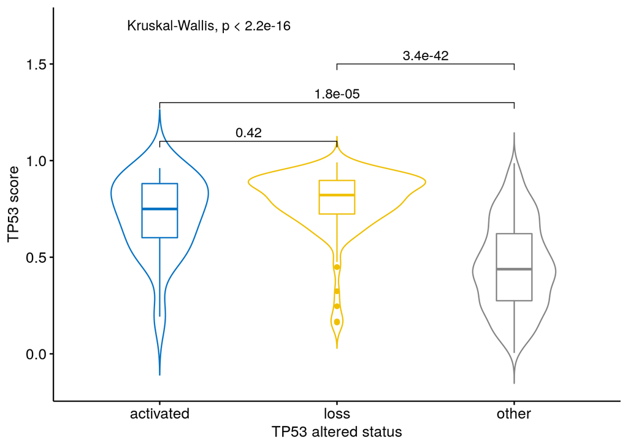

```r
# Create plot
ggviolin(tp53_alterations_score_wide, x = "tp53_altered", y = "tp53_score",
         color = "tp53_altered",
         palette = "jco",
         order = c("activated", "loss", "other"),
         add = "boxplot",
         ggtheme = theme_pubr()) +
  # Default method = "kruskal.test" for multiple groups
  # Add adjusted p-value - has to be done manually and from a table - pulling from table above
  stat_pvalue_manual(adj, label = "p.adj", y.position = c(1.5, 1.3, 1.1)) +
  # Add global p-value
  stat_compare_means(label.y = 1.7) +
  xlab("TP53 altered status") +
  ylab("TP53 score") +
  rremove("legend")
```

```r
# This plot does not need to be saved if tumor purity threshold is on
if (params$tumor_purity_threshold == 0){
  ggsave(file.path(plot_dir, "tp53_scores_by_altered_status.png"))
}
```

TP53 mutants with gain-of-function (activating) mutants promote tumorigenesis according to literature. [Reference](https://pubmed.ncbi.nlm.nih.gov/17417627/) and [reference](https://pubmed.ncbi.nlm.nih.gov/24677579/) have similar distribution of classifier scores to that of potential loss-of-function (multi-allelic) Tp53 mutations.

“Other” annotated samples either don’t have any high-confidence loss/gain TP53 SNVs nor CNV losses OR DNA sample is not available.

### (stranded) Expression profile for activating vs loss TP53 status

```r
stranded <- readRDS(file.path(data_dir,"pbta-gene-expression-rsem-fpkm-collapsed.stranded.rds"))

# This needs to be filtered down if tumor purity is on
if (params$tumor_purity_threshold == 1) {

  # Define path to tumor purity module
  tumor_purity_dir <- file.path(
    rprojroot::find_root(rprojroot::has_dir(".git")),
    "analyses",
    "tumor-purity-exploration"
  )

  # Define path to metadata file which has been filtered to only biospecimens that
  #  survive the cancer-group-level threshold
  tumor_purity_file <- file.path(
    tumor_purity_dir,
    "results",
    "thresholded_rna_stranded_same-extraction.tsv"
  )

  # Load the function to filter IDs
  source(
    file.path(tumor_purity_dir, "util", "function_filter-by-threshold.R")
  )

  # Filter the expression data
  stranded <- filter_expression_by_tumor_purity(stranded,
                                                tumor_purity_file)
}


# subset to TP53
subset_stranded <- t(stranded)[,"TP53"]

stranded_tp53 <- as.data.frame(subset_stranded) %>%
  dplyr::rename(TP53=subset_stranded) %>%
  rownames_to_column() %>%
  left_join(tp53_alterations_score_wide, by = c("rowname" = "Kids_First_Biospecimen_ID_RNA")) %>%
  # remove polya from matched scores
  filter(tp53_altered %in% c("activated","loss"))

# Print table of n per group for legends
stranded_tp53 %>%
  filter(!is.na(tp53_score)) %>%
  group_by(tp53_altered) %>%
  tally()
```

| tp53_altered | n |
| --- | --- |
| activated | 11 |
| loss | 100 |

Plot distribution of TP53 gene expression (stranded)

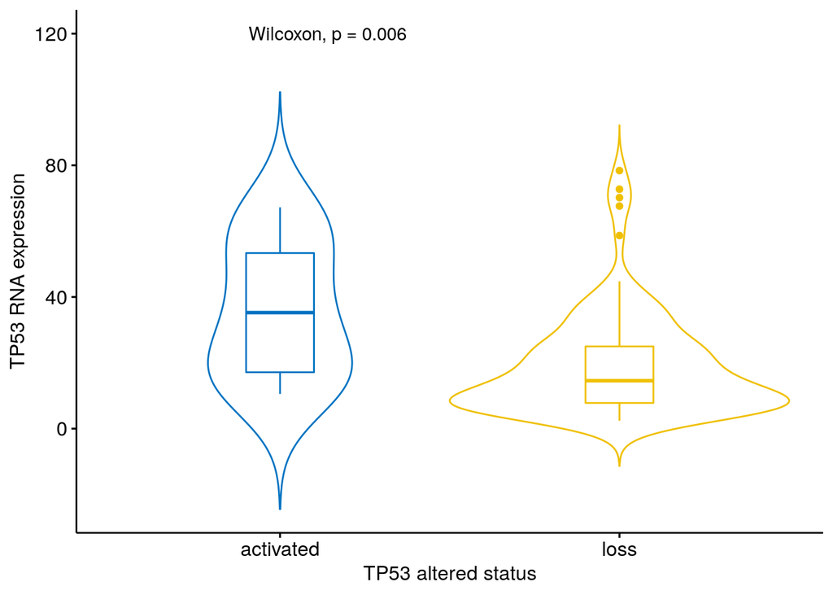

```r
ggviolin(stranded_tp53, x = "tp53_altered", y = "TP53",
         color = "tp53_altered",
         palette = "jco",
         order = c("activated", "loss"),
         add = "boxplot",
         ggtheme = theme_pubr()) +
  # Add pairwise comparisons p-value
  stat_compare_means(method = "wilcox.test", label.y = 120) +
  xlab("TP53 altered status") +
  ylab("TP53 RNA expression") +
  rremove("legend")
```

```r
# This plot does not need to be saved if tumor purity threshold is on
if (params$tumor_purity_threshold == 0){
  ggsave(file.path(plot_dir, "tp53_expression_by_altered_status_stranded.png"))
}
```

### (poly-a) Expression profile for activating vs loss TP53 status

```r
polya <- readRDS(file.path(data_dir,"pbta-gene-expression-rsem-fpkm-collapsed.polya.rds"))

# subset to TP53
subset_polya <- t(polya)[,"TP53"]

polya_tp53<- as.data.frame(subset_polya) %>%
  dplyr::rename(TP53=subset_polya) %>%
  rownames_to_column() %>%
  left_join(tp53_alterations_score_wide,by=c("rowname"="Kids_First_Biospecimen_ID_RNA")) %>%
  filter(tp53_altered %in% c("activated","loss"))

# Print table of n per group for legends
polya_tp53 %>%
  filter(!is.na(tp53_score)) %>%
  group_by(tp53_altered) %>%
  tally()
```

| tp53_altered | n |
| --- | --- |
| activated | 7 |
| loss | 22 |

Plot distribution of TP53 gene expression (poly-a)

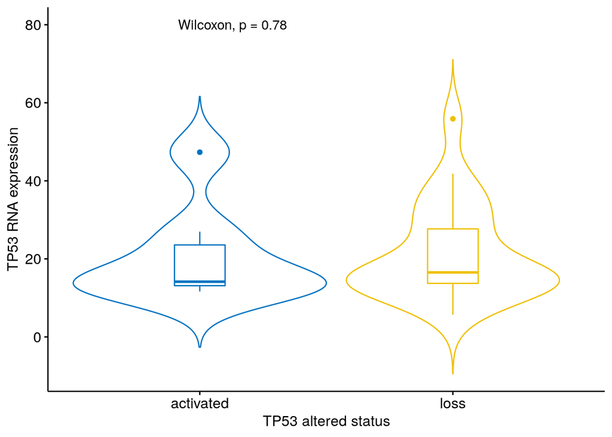

```r
ggviolin(polya_tp53, x = "tp53_altered", y = "TP53",
         color = "tp53_altered",
         palette = "jco",
         order = c("activated", "loss"),
         add = "boxplot",
         ggtheme = theme_pubr()) +
  # Add pairwise comparisons p-value
  stat_compare_means(method = "wilcox.test", label.y = 80) +
  xlab("TP53 altered status") +
  ylab("TP53 RNA expression") +
  rremove("legend")
```

```r
ggsave(file.path(plot_dir, "tp53_expression_by_altered_status_polya.png"))
```

### Check if other cancer predisposition have high TP53 inactivation scores

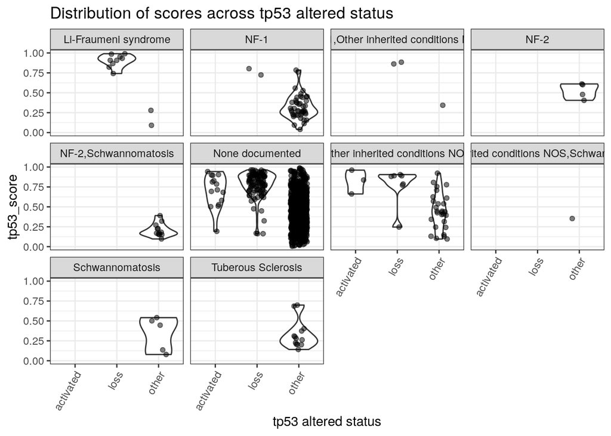

```r
ggplot(tp53_alterations_score_wide, aes(x = factor(tp53_altered), y = tp53_score)) +
  geom_violin()+
  geom_jitter(alpha = 0.5, width = 0.2) +
  theme_bw() +
  ggtitle("Distribution of scores across tp53 altered status") +
  theme(axis.text.x = element_text(angle = 60, hjust = 1))+
  xlab("tp53 altered status") +
  facet_wrap(.~cancer_predispositions)
```

### Li-Fraumeni syndrome (table of tp53 scores per tp53 altered status)

```r
# plot lfs for manuscript
lfs <- tp53_alterations_score_wide %>%
  filter(cancer_predispositions == "Li-Fraumeni syndrome")

lfs %>%
  filter(!is.na(tp53_score)) %>%
  group_by(tp53_altered) %>%
  tally()
```

| tp53_altered | n |
| --- | --- |
| loss | 9 |
| other | 2 |

# Li-Fraumeni syndrome (plot tp53 scores per tp53 altered status)

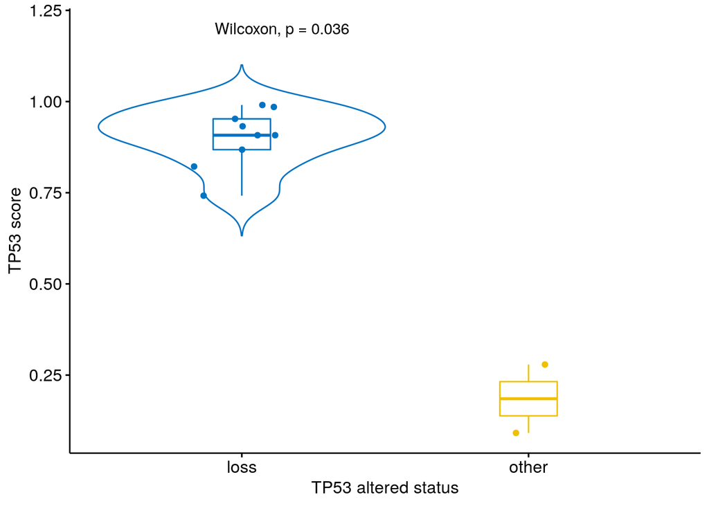

```r
ggviolin(lfs, x = "tp53_altered", y = "tp53_score",
         color = "tp53_altered",
         palette = "jco",
         order = c("loss", "other"),
         add = c("boxplot", "jitter"),
   ggtheme = theme_pubr()) +
  # Add pairwise comparisons p-value
  stat_compare_means(method = "wilcox.test", label.y = 1.2) +
  xlab("TP53 altered status") +
  ylab("TP53 score") +
  rremove("legend")
```

### Table of scores across tp53 altered status by cancer predisposition

```r
# table of scores across tp53 altered status by cancer predisposition
tp53_alterations_score_wide %>% filter(!is.na(cancer_predispositions)) %>%
  group_by(cancer_predispositions, tp53_altered) %>%
  filter(!is.na(tp53_score)) %>%
  tally()
```

| cancer_predispositions | tp53_altered | n |
| --- | --- | --- |
| Li-Fraumeni syndrome | loss | 9 |
| Li-Fraumeni syndrome | other | 2 |
| NF-1 | loss | 2 |
| NF-1 | other | 44 |
| NF-1,Other inherited conditions NOS | loss | 2 |
| NF-1,Other inherited conditions NOS | other | 1 |
| NF-2 | other | 4 |
| NF-2,Schwannomatosis | other | 12 |
| None documented | activated | 15 |
| None documented | loss | 102 |

[output cut: 7 more lines]

# Plot of scores across tp53 altered status by cancer predisposition

```r
# This chunk does not need to be run if tumor purity threshold is on
if (params$tumor_purity_threshold == 0){
  # plot of scores across tp53 altered status by cancer predisposition
  d_ply(tp53_alterations_score_wide %>%
          filter(!is.na(cancer_predispositions),
                 !is.na(tp53_score)), .variables = "cancer_predispositions",
        .fun = function(x) plot_by_cancer_predisposition(lfs = x, plot_dir))
}
```

Some NF-1 and/or Other inherited conditions NOS have high scoring TP53 mutants as well.

Interesting 2 bs ids annotated with Li-Fraumeni synfrome pre-disposition have very low tp53 classifier scores.

```r
tp53_alterations_score_wide %>%
  filter(cancer_predispositions == "Li-Fraumeni syndrome",
         tp53_score < 0.5)
```

| sample_id | Kids_First_Biospecimen_ID_DNA | Kids_First_Biospecimen_ID_RNA | cancer_predispositions | tp53_score | SNV_indel_counts | CNV_loss_counts | SV_counts | Fusion_counts | HGVSp_Short | CNV_loss_evidence | SV_type | Fusion_evidence | hotspot | activating | tp53_altered |
| --- | --- | --- | --- | --- | --- | --- | --- | --- | --- | --- | --- | --- | --- | --- | --- |
| 7316-2310 | BS_Z9PKZ4RT | BS_DEHJF4C7 | Li-Fraumeni syndrome | 0.09144415 | 0 | 0 | 0 | 0 | NA | NA | NA | NA | 0 | 0 | other |
| 7316-445 | BS_G9MQM1KK | BS_ZD5HN296 | Li-Fraumeni syndrome | 0.27898380 | 0 | 0 | 0 | 0 | NA | NA | NA | NA | 0 | 0 | other |

## Save file

Adding DNA and RNA biospecimen ids to `tp53_alterations_score_wide` and saving

```r
tp53_alterations_score_wide %>%
  write_tsv(file.path(results_dir,
                      glue::glue("tp53_altered_status{tumor_purity_suffix}.tsv")))
```